### 3 Vorhersage der Fluktuation II

#### 3.1 Einführung

In diesem Kapitel wird die **Fluktuation** mithilfe von **Maschinellem Lernen** vorhergesagt. Unter Zuhilfenahme des Caret-Pakets werden drei Algorithmen trainiert und evaluiert. Von den drei trainierten Modellen wird dann das beste ausgewählt und die Wichtigkeit einzelner Prädiktoren untersucht.

#### 3.2 Pakete installieren und laden

```r
packages <- c("caret", "ranger", "lsr", "ggplot2", "rsample", "data.table",
              "e1071", "grid", "tidyverse", "MLeval", "here", "rio")

lapply(packages, function(package){
  if (!require(package, character.only = TRUE)) {
    install.packages(package, dependencies = TRUE)
  }
  library(package, character.only = TRUE)
})
```

#### 3.3 Arbeitsverzeichnis festlegen

```r
here::here()
```

#### 3.4 Datenimport

```r
# Rohdaten importieren
mitarbeiter_data <- rio::import(file = "HRDataset_v14_4.csv")

str(mitarbeiter_data)
```

```
## 'data.frame':    311 obs. of  9 variables:
##  $ Salary              : int  62506 104437 64955 64991 50825 57568 95660 59365 47837 50178 ...
##  $ DateofHire          : chr  "7/5/2011" "3/30/2015" "7/5/2011" "1/7/2008" ...
##  $ PerformanceScore    : chr  "Exceeds" "Fully Meets" "Fully Meets" "Fully Meets" ...
##  $ EngagementSurvey    : chr  "4,6" "4,96" "3,02" "4,84" ...
##  $ EmpSatisfaction     : int  5 3 3 5 4 5 3 4 3 5 ...
##  $ SpecialProjectsCount: int  0 6 0 0 0 0 4 0 0 6 ...
##  $ DaysLateLast30      : int  0 0 0 0 0 0 0 0 0 0 ...
##  $ Absences            : int  1 17 3 15 2 15 19 19 4 16 ...
##  $ Fluktuation         : chr  "verblieben" "gegangen" "gegangen" "verblieben" ...
```

#### 3.5 Pre-Processing

##### Anstellungsdatum in „Anstellungsdauer (in Tagen)“ umwandeln

Das Anstellungsdatum wird in ein Datumsformat konvertiert und die Dauer der Anstellung in Tagen berechnen. Das ursprüngliche Datum wird danach entfernt, da es nicht mehr benötigt wird.

```r
mitarbeiter_data$DateofHire <- as.Date(mitarbeiter_data$DateofHire, format = "%m/%d/%Y")
mitarbeiter_data$DaysSinceHire <- as.numeric(Sys.Date() - mitarbeiter_data$DateofHire)
mitarbeiter_data$DateofHire <- NULL
```

##### Outcome-Variable faktorisieren

Die Zielvariable “Fluktuation” wird in einen Faktor umgewandelt, damit sie in den Modellen korrekt verarbeitet werden kann.

```r
mitarbeiter_data$Fluktuation <- factor(x = mitarbeiter_data$Fluktuation,
                                       levels = c("verblieben", "gegangen"))
```

##### Variable von character-Format in numerisches Format umwandeln

Die Variable “EngagementSurvey” wird von einem Zeichen- in ein numerisches Format konvertiert, um sie für die Modellierung vorzubereiten.

```r
mitarbeiter_data$EngagementSurvey <- sub(",", ".", mitarbeiter_data$EngagementSurvey)
mitarbeiter_data$EngagementSurvey <- as.numeric(mitarbeiter_data$EngagementSurvey)
```

##### Dummy-Variablen erstellen

Da das caret-Paket nur ein numerisches Format bei den Prädiktoren zulässt, werden für die kategoriale Variable “PerformanceScore” Dummy-Variablen erstellt.

```r
dummyVars <- caret::dummyVars(~ PerformanceScore, data = mitarbeiter_data)
performance_dummy <- predict(dummyVars, newdata = mitarbeiter_data)
mitarbeiter_data$perfromance_dummy <- performance_dummy
mitarbeiter_data$PerformanceScore <- NULL
str(mitarbeiter_data)
```

```
## 'data.frame':    311 obs. of  9 variables:
##  $ Salary              : int  62506 104437 64955 64991 50825 57568 95660 59365 47837 50178 ...
##  $ EngagementSurvey    : num  4.6 4.96 3.02 4.84 5 5 3.04 5 4.46 5 ...
##  $ EmpSatisfaction     : int  5 3 3 5 4 5 3 4 3 5 ...
##  $ SpecialProjectsCount: int  0 6 0 0 0 0 4 0 0 6 ...
##  $ DaysLateLast30      : int  0 0 0 0 0 0 0 0 0 0 ...
##  $ Absences            : int  1 17 3 15 2 15 19 19 4 16 ...
##  $ Fluktuation         : Factor w/ 2 levels "verblieben","gegangen": 1 2 2 1 2 1 1 1 1 1 ...
##  $ DaysSinceHire       : num  4857 3493 4857 6132 4851 ...
##  $ perfromance_dummy   : num [1:311, 1:4] 1 0 0 0 0 1 0 0 0 0 ...
##   ..- attr(*, "dimnames")=List of 2
##   .. ..$ : chr [1:311] "1" "2" "3" "4" ...
##   .. ..$ : chr [1:4] "PerformanceScoreExceeds" "PerformanceScoreFully Meets" "PerformanceScoreNeeds Improvement" "PerformanceScorePIP"
```

##### Trainings- und Testdaten aufteilen

Die Daten werden in Trainings- (80%) und Testdaten (20%) aufgeteilt, um die Modelle zu trainieren und später deren Leistung zu bewerten.

```r
trainIndex <- caret::createDataPartition(mitarbeiter_data$Fluktuation, p = .8, list = FALSE)
mitarbeiterTrain <- mitarbeiter_data[ trainIndex,]
mitarbeiterTest  <- mitarbeiter_data[-trainIndex,]
```

Wir verwenden eine wiederholte 10-fache Kreuzvalidierung, um die Modelle zu trainieren. Diese Methode hilft, die Modelle robust gegenüber Überanpassungen zu machen.

```r
train_control <- trainControl(method = "repeatedcv", number = 10, repeats = 3,
                              savePredictions = "all")
```

#### 3.6 Modelltraining

##### Training: Gradient-boosting Machine

Hier wird ein Gradient Boosting Modell (gbm) trainiert, wobei Genauigkeit (Accuracy) als Leistungskennzahl verwendet wird. Die Ergebnisse und die Lernkurve werden anschließend visualisiert.

```r
set.seed(42)
model_gbm <- train(
  Fluktuation ~.,
  data = mitarbeiterTrain,
  trControl = train_control,
  method = "gbm",
  metric = "Accuracy",
  verbose = FALSE)

print(model_gbm)
```

```
## Stochastic Gradient Boosting
##
## 250 samples
##   8 predictor
##   2 classes: 'verblieben', 'gegangen'
##
## No pre-processing
## Resampling: Cross-Validated (10 fold, repeated 3 times)
## Summary of sample sizes: 226, 226, 225, 225, 224, 226, ...
## Resampling results across tuning parameters:
##
##   interaction.depth  n.trees  Accuracy   Kappa
##   1                   50      0.7544060  0.4212351
##   1                  100      0.7518462  0.4155701
##   1                  150      0.7559017  0.4231257
##   2                   50      0.7569231  0.4326061
##   2                  100      0.7531239  0.4312350
##   2                  150      0.7555812  0.4346037
##   3                   50      0.7529231  0.4249013
##   3                  100      0.7485897  0.4137641
##   3                  150      0.7373205  0.3967294
##
## Tuning parameter 'shrinkage' was held constant at a value of 0.1
##
## Tuning parameter 'n.minobsinnode' was held constant at a value of 10
## Accuracy was used to select the optimal model using the largest value.
## The final values used for the model were n.trees = 50, interaction.depth =
##  2, shrinkage = 0.1 and n.minobsinnode = 10.
```

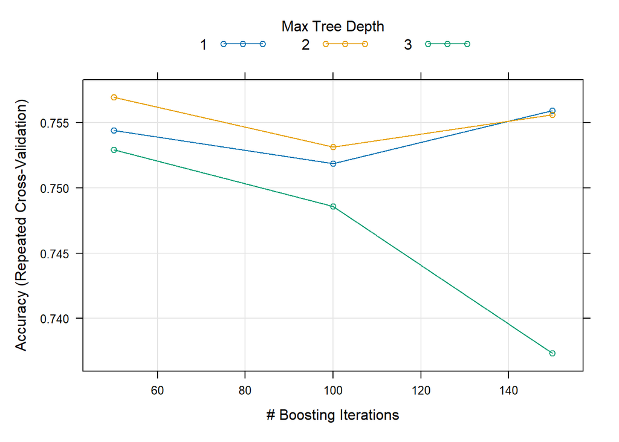

```r
plot(model_gbm)
```

##### Training: Support-Vector-Machine mit linearem Kernel

Ein Support-Vector-Machine Modell mit linearem Kernel wird trainiert. Auch hier werden die Ergebnisse und die Lernkurve visualisiert.

```r
set.seed(42)
model_svm <- train(
  Fluktuation ~.,
  data = mitarbeiterTrain,
  trControl = train_control,
  method = "svmLinear2")

print(model_svm)
```

```
## Support Vector Machines with Linear Kernel
##
## 250 samples
##   8 predictor
##   2 classes: 'verblieben', 'gegangen'
##
## No pre-processing
## Resampling: Cross-Validated (10 fold, repeated 3 times)
## Summary of sample sizes: 226, 226, 225, 225, 224, 226, ...
## Resampling results across tuning parameters:
##
##   cost  Accuracy   Kappa
##   0.25  0.6424957  0.04633007
##   0.50  0.6425000  0.05397624
##   1.00  0.6478333  0.07387031
##
## Accuracy was used to select the optimal model using the largest value.
## The final value used for the model was cost = 1.
```

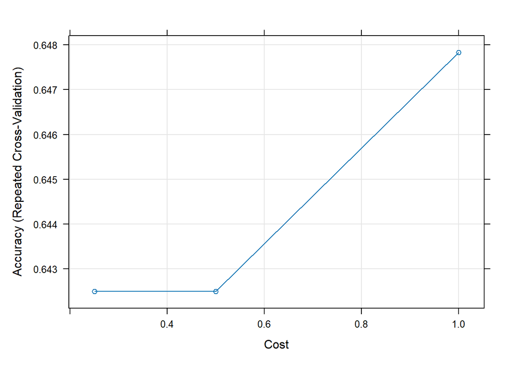

```r
plot(model_svm)
```

##### Training: Random Forest

Ein Random Forest Modell (ranger) wird trainiert. Es wird die impurity-Metrik zur Bewertung der Variablenwichtigkeit verwendet.

```r
model_rf <- train(
  Fluktuation ~.,
  data = mitarbeiterTrain,
  trControl = train_control,
  method = "ranger",
  importance = "impurity",
  metric = "Accuracy")

print(model_rf)
```

```
## Random Forest
##
## 250 samples
##   8 predictor
##   2 classes: 'verblieben', 'gegangen'
##
## No pre-processing
## Resampling: Cross-Validated (10 fold, repeated 3 times)
## Summary of sample sizes: 226, 225, 226, 224, 225, 226, ...
## Resampling results across tuning parameters:
##
##   mtry  splitrule   Accuracy   Kappa
##    2    gini        0.7292051  0.36086664
##    2    extratrees  0.6694316  0.06138407
##    6    gini        0.7236368  0.36309962
##    6    extratrees  0.7022906  0.31227270
##   11    gini        0.7167009  0.34930023
##   11    extratrees  0.7088120  0.33222337
##
## Tuning parameter 'min.node.size' was held constant at a value of 1
## Accuracy was used to select the optimal model using the largest value.
## The final values used for the model were mtry = 2, splitrule = gini
##  and min.node.size = 1.
```

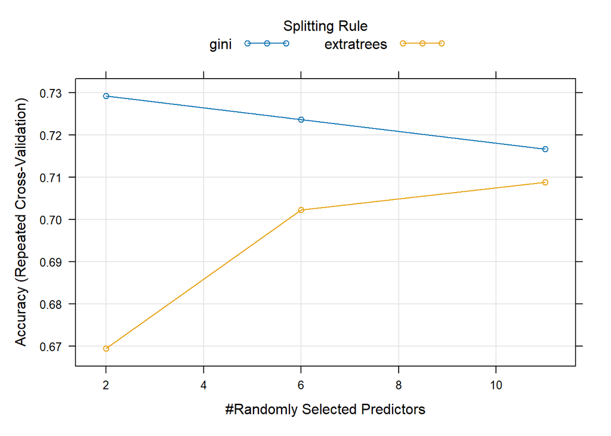

```r
plot(model_rf)
```

#### 3.7 Modellvergleich

```r
results <- resamples(list(GBM = model_gbm, RF = model_rf, SVM = model_svm))
summary(results)
```

```
##
## Call:
## summary.resamples(object = results)
##
## Models: GBM, RF, SVM
## Number of resamples: 30
##
## Accuracy
##          Min.   1st Qu.    Median      Mean   3rd Qu.      Max. NA's
## GBM 0.5600000 0.7112500 0.7596154 0.7569231 0.8269231 0.9230769    0
## RF  0.6250000 0.6830769 0.7253846 0.7292051 0.7669231 0.8333333    0
## SVM 0.5384615 0.6153846 0.6400000 0.6478333 0.7043269 0.7600000    0
##
## Kappa
##              Min.     1st Qu.     Median       Mean   3rd Qu.      Max. NA's
## GBM -4.562738e-02  0.32049230 0.43103448 0.43260612 0.5835582 0.8300654    0
## RF   2.960595e-16  0.30714832 0.36402157 0.36086664 0.4596904 0.6000000    0
## SVM -1.538462e-01 -0.07638179 0.04081633 0.07387031 0.1967480 0.3157895    0
```

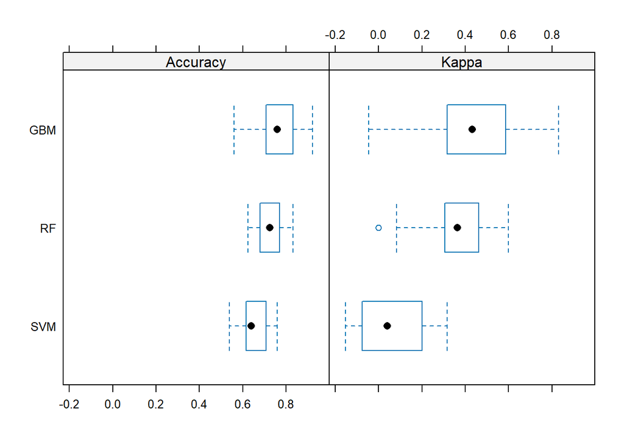

```r
bwplot(results)
```

Die Bewertung erfolgt anhand zweier Metriken: Accuracy (Genauigkeit) und Kappa (Maß für die Übereinstimmung).

#### 3.8 Modellevaluation

##### Evaluation in Testdatensatz

```r
predicted_test_GBM <- predict(model_gbm, newdata = mitarbeiterTest)
confusionMatrix(predicted_test_GBM, mitarbeiterTest$Fluktuation, mode = "everything")
```

```
## Confusion Matrix and Statistics
##
##             Reference
## Prediction   verblieben gegangen
##   verblieben         36        7
##   gegangen            5       13
##
##                Accuracy : 0.8033
##                  95% CI : (0.6816, 0.894)
##     No Information Rate : 0.6721
##     P-Value [Acc > NIR] : 0.01733
##
##                   Kappa : 0.5419
##
##  Mcnemar's Test P-Value : 0.77283
##
##             Sensitivity : 0.8780
##             Specificity : 0.6500
##          Pos Pred Value : 0.8372
##          Neg Pred Value : 0.7222
##               Precision : 0.8372
##                  Recall : 0.8780
##                      F1 : 0.8571
##              Prevalence : 0.6721
##          Detection Rate : 0.5902
##    Detection Prevalence : 0.7049
##       Balanced Accuracy : 0.7640
##
##        'Positive' Class : verblieben
##
```

```r
predicted_test_RF <- predict(model_rf, newdata = mitarbeiterTest)
confusionMatrix(predicted_test_RF, mitarbeiterTest$Fluktuation, mode = "everything")
```

```
## Confusion Matrix and Statistics
##
##             Reference
## Prediction   verblieben gegangen
##   verblieben         40       10
##   gegangen            1       10
##
##                Accuracy : 0.8197
##                  95% CI : (0.7002, 0.9064)
##     No Information Rate : 0.6721
##     P-Value [Acc > NIR] : 0.007899
##
##                   Kappa : 0.5376
##
##  Mcnemar's Test P-Value : 0.015861
##
##             Sensitivity : 0.9756
##             Specificity : 0.5000
##          Pos Pred Value : 0.8000
##          Neg Pred Value : 0.9091
##               Precision : 0.8000
##                  Recall : 0.9756
##                      F1 : 0.8791
##              Prevalence : 0.6721
##          Detection Rate : 0.6557
##    Detection Prevalence : 0.8197
##       Balanced Accuracy : 0.7378
##
##        'Positive' Class : verblieben
##
```

```r
predicted_test_svm <- predict(model_svm, newdata = mitarbeiterTest)
confusionMatrix(predicted_test_svm, mitarbeiterTest$Fluktuation, mode = "everything")
```

```
## Confusion Matrix and Statistics
##
##             Reference
## Prediction   verblieben gegangen
##   verblieben         39       15
##   gegangen            2        5
##
##                Accuracy : 0.7213
##                  95% CI : (0.5917, 0.8285)
##     No Information Rate : 0.6721
##     P-Value [Acc > NIR] : 0.250522
##
##                   Kappa : 0.2414
##
##  Mcnemar's Test P-Value : 0.003609
##
##             Sensitivity : 0.9512
##             Specificity : 0.2500
##          Pos Pred Value : 0.7222
##          Neg Pred Value : 0.7143
##               Precision : 0.7222
##                  Recall : 0.9512
##                      F1 : 0.8211
##              Prevalence : 0.6721
##          Detection Rate : 0.6393
##    Detection Prevalence : 0.8852
##       Balanced Accuracy : 0.6006
##
##        'Positive' Class : verblieben
##
```